# Investigating various variables such as the Age, Passenger Class, Fare and gender resulted in determining survivors in titanic dataset.

# By Dennis Muigo

# INTRODUCTION

# The main feature of interest in this dataset is to know the number of survivors

I am most interested in features that will predict passengers who survived.

Those features are Age, Fare, and class

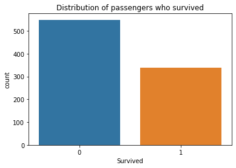

```python
sns.countplot(data = titanic, x = 'Survived')
plt.title("Distribution of passengers who survived");
```

```python
titanic.Survived.value_counts()
```

```
0    549
1    340
Name: Survived, dtype: int64
```

# 2.2 Observation

From the observation we can see majority of passengers did not survive, 549 did not make it compared to 340 who survived

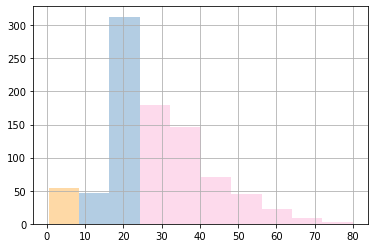

```python
# set the colors
cmap = plt.get_cmap('Pastel1')
young = cmap(0.5)
middle = cmap(0.2)
older = cmap(0.8)

# get the object we will change - patches is an array with len: num of bins
fig, ax = plt.subplots()
y_values, bins, patches = ax.hist(titanic.Age, 10)

[patches[i].set_facecolor(young) for i in range(0,1)] # bin 0
[patches[i].set_facecolor(middle) for i in range(1,3)] # bins 1 and 2
[patches[i].set_facecolor(older) for i in range(3,10)] # 7 remaining bins

ax.grid(True)
fig.show();
```

# 2.4.4 Observation

Those Passengers aged 20 were many followed by 30 years and 40 years.

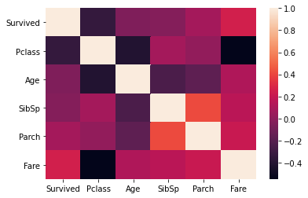

```python
#plotting the correlation in a heatmap
sns.heatmap(corr);
```

# Observation

There is fairly positive relationship between siblings and parents aboard Also a negative linear relationship between the passengers class and Fare

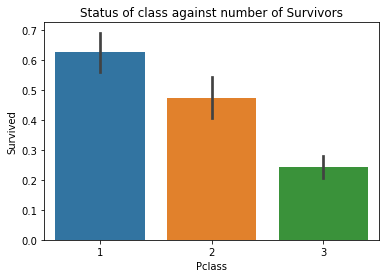

```python
#we can make an observation that the status of the class determined the number of survivors
sns.barplot(x = 'Pclass', y='Survived',data=titanic)
plt.title("Status of class against number of Survivors");
```

```python
y = titanic.groupby('Pclass')['Survived'].sum()
y
```

```
Pclass
1    134
2     87
3    119
Name: Survived, dtype: int64
```

# 2.7.2 Observation

passengers who survived more according to the class they boarded were FIrst class, followed by Second and third class had few number of survivors

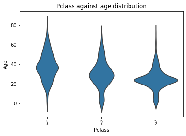

```python
base_color = sns.color_palette()[0]
sns.violinplot(data=titanic, x='Pclass', y='Age', color = base_color, inner = None);
plt.xticks(rotation = 15)
plt.title('Pclass against age distribution');
```

# 2.9.2 Observation

For each of the passenger class an area is plotted that show an area is plotted that shows an approximate age for passenger class. Those passengers who were on Third class majority of them were below 30 years.

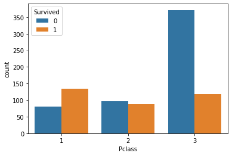

```python
#plotting the countplot
sns.countplot(data = titanic, x = 'Pclass', hue = 'Survived');
```

# 3.1.1 Observation

grouped with classes, first class number of passengers who survived exceeded those who did not survive, while those in the second class were farely balanced between survivors and non-survivors. For the third class is where majority succumbed to the tragic.

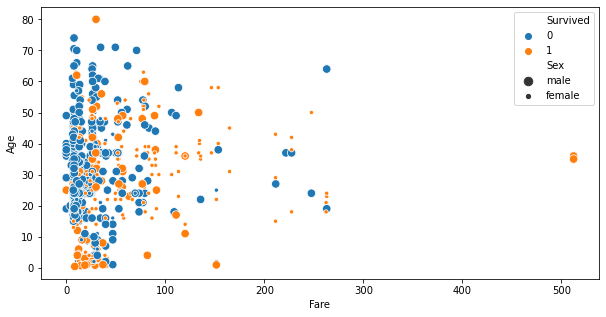

```python
f, ax = plt.subplots(1,1, figsize=(10, 5))
sns.scatterplot(x="Fare", y="Age", hue="Survived", size="Sex", data=titanic, ax=ax);
```

# 4.2.2 Observation

# TAKE AWAY

After a close examination in our dataset, the two qualitative variables, Pclass and Sex had a linear relationship with the number of survivors in the titanic.

First class had the highest number of survivors 134 of them, followed by third class with 119 and second class had 87 survivors.

Females survived more than males